# Setting a bounding box

By default, ggplot will plot the an area that includes all the data in all the layers you add to your map. However, in some cases, you might want to “zoom in” on part of the map without having to clip or filter the underlying data.

# Required packages

This example uses the following packages:

```r
library(tidyverse)
library(rnaturalearth)
library(sf)
```

# Sample data

Here is a map of countries in Africa

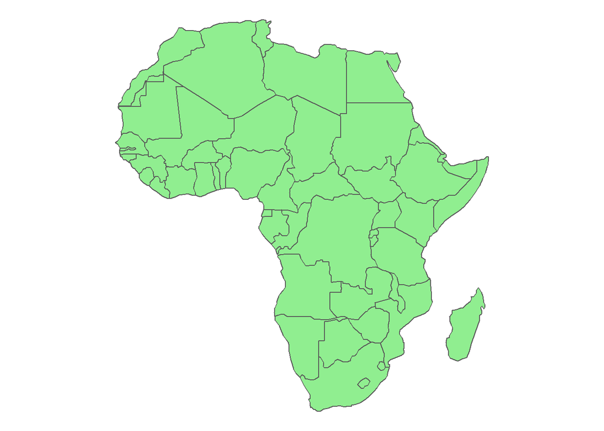

```r
countries <- ne_countries(continent = "Africa",
                          returnclass = "sf")

ggplot(countries) +
  geom_sf(fill = "palegreen2") +
  theme_void()
```

I might also want to show the adjacent landmasses (parts of Europe and Asia), in gray. I can load the shapes of all the world countries and plot them under my map of Africa, but now it’s a map of the world, and Africa is really small (especially given the map projection, but that’s [another topic](https://c-voulgaris.github.io/VIS-2128-F22/a2-files/skill-ggplot-proj.html)).

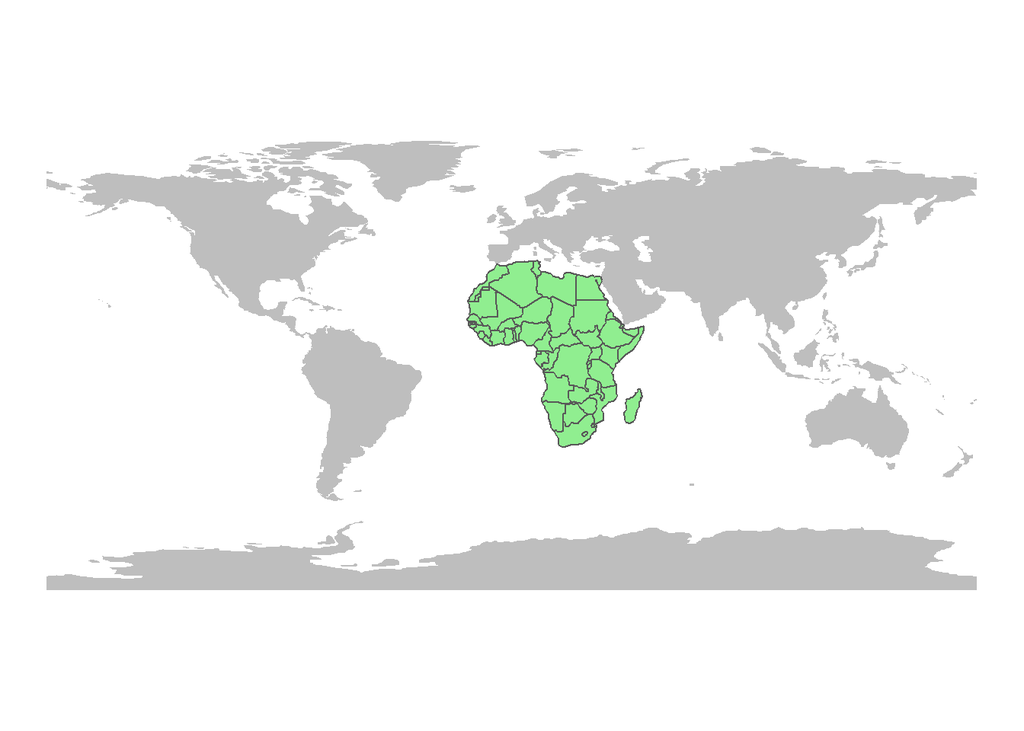

```r
world <- ne_countries(returnclass = "sf")

ggplot(countries) +
  geom_sf(data= world,
          color = NA, fill = "gray") +
  geom_sf(fill = "palegreen2") +
  theme_void()
```

Here’s how I get the map’s bounding box back to where it was.

# Get the bounding box for a layer

The function `st_bbox()` will return the bounding box for a geospatial data layer.

```r
st_bbox(countries)
```

```
##      xmin      ymin      xmax      ymax
## -17.62504 -34.81917  51.13387  37.34999
```

And I can store these values in separate variables.

```r
africa_xmin <- st_bbox(countries)$xmin
africa_xmax <- st_bbox(countries)$xmax

africa_ymin <- st_bbox(countries)$ymin
africa_ymax <- st_bbox(countries)$ymax
```

# Set the bounding box for your map

Now I can use the `coord_sf()` function to set the extent of my map.

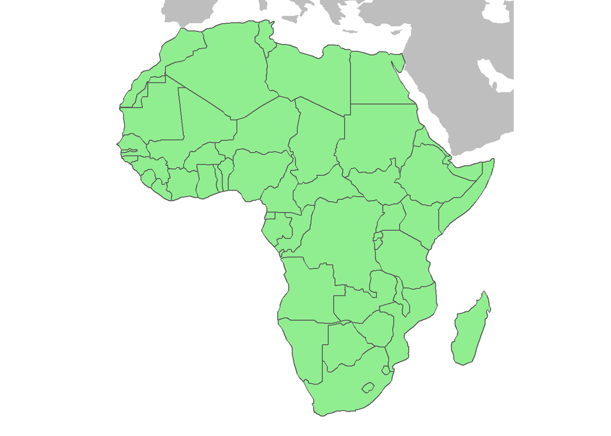

```r
ggplot(countries) +
  geom_sf(data= world,
          color = NA, fill = "gray") +
  geom_sf(fill = "palegreen2") +
  theme_void() +
  coord_sf(xlim = c(africa_xmin, africa_xmax),
           ylim = c(africa_ymin, africa_ymax))
```

Note that `coord_sf()` is also the function you’d use to [change the map projection](https://c-voulgaris.github.io/VIS-2128-F22/a2-files/skill-ggplot-proj.html)